# ggplot

Pao

July 21, 2019

Notas sobre algunos capítulos de R for Data Science.

## Capítulo 3

El paquete `ggplot2` es la gloría para graficar y funciona con una estructura de capas. La primera función que se usa es `ggplot()` que crea el área del gŕafico, necesita el dataframe y las variables a graficar. Luego se le suma el `geom_`que se quiere graficar, podrían ser puntos, líneas o casi cualquier cosa.

La función `glimpse()`parece ser análoga a `str()`.

```r
glimpse(mpg)
```

```
## Observations: 234
## Variables: 11
## $ manufacturer <chr> "audi", "audi", "audi", "audi", "audi", "audi", "au…
## $ model        <chr> "a4", "a4", "a4", "a4", "a4", "a4", "a4", "a4 quatt…
## $ displ        <dbl> 1.8, 1.8, 2.0, 2.0, 2.8, 2.8, 3.1, 1.8, 1.8, 2.0, 2…
## $ year         <int> 1999, 1999, 2008, 2008, 1999, 1999, 2008, 1999, 199…
## $ cyl          <int> 4, 4, 4, 4, 6, 6, 6, 4, 4, 4, 4, 6, 6, 6, 6, 6, 6, …
## $ trans        <chr> "auto(l5)", "manual(m5)", "manual(m6)", "auto(av)",…
## $ drv          <chr> "f", "f", "f", "f", "f", "f", "f", "4", "4", "4", "…
## $ cty          <int> 18, 21, 20, 21, 16, 18, 18, 18, 16, 20, 19, 15, 17,…
## $ hwy          <int> 29, 29, 31, 30, 26, 26, 27, 26, 25, 28, 27, 25, 25,…
## $ fl           <chr> "p", "p", "p", "p", "p", "p", "p", "p", "p", "p", "…
## $ class        <chr> "compact", "compact", "compact", "compact", "compac…
```

Se le llama *valor* a lo que describe los datos y *nivel* a lo que describe propiedades estéticas (color, forma, tamaño de un punto, etc.).

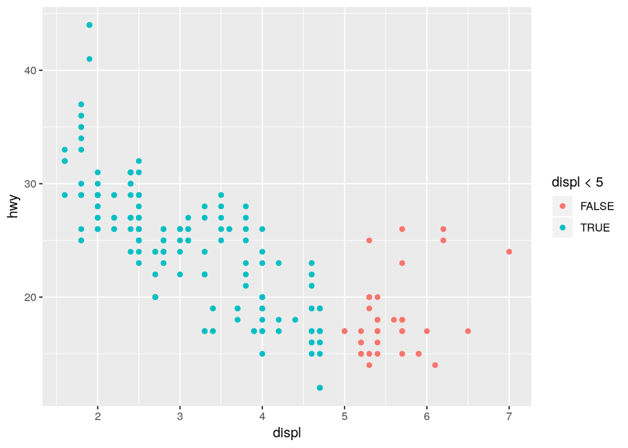

```r
ggplot(mpg, aes(x = displ, y = hwy, colour = displ < 5)) +
  geom_point()
```

Mirá que interesante: si agregás `colour = displ < 5` dentro del `aes` internamente te genera dos categorías y las mapea al color! Medio desprolijo pero rápido para explorar los datos.

### Facet

¿Qué hay detrás de la sintaxis de dvr ~ .? *VER*

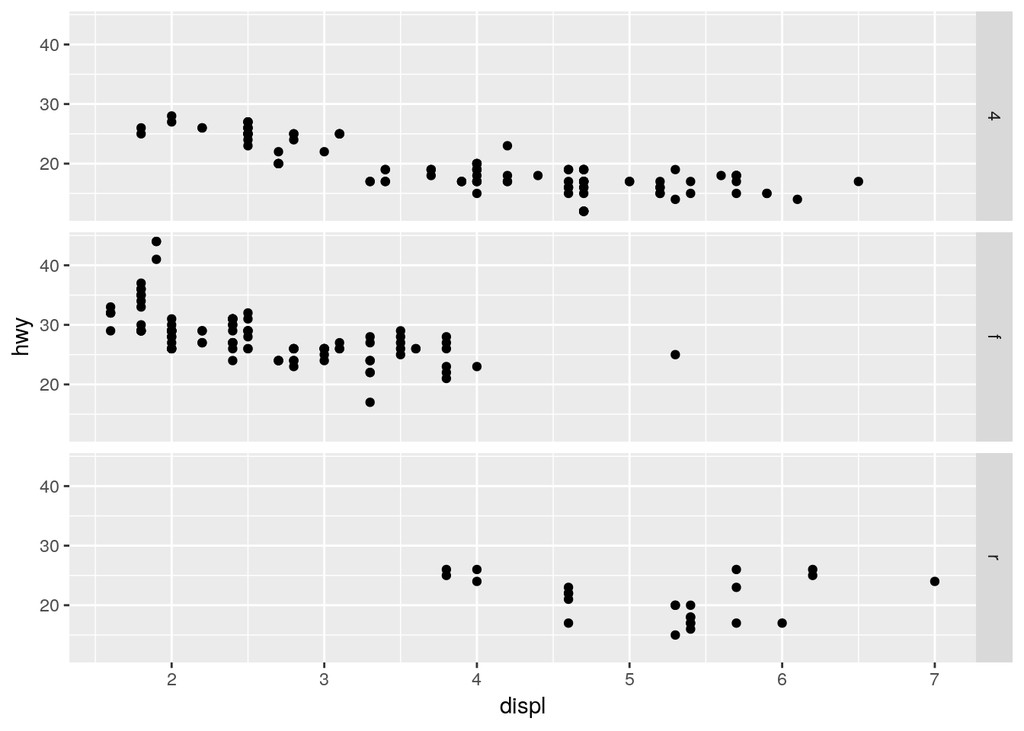

```r
ggplot(data = mpg) +
  geom_point(mapping = aes(x = displ, y = hwy)) +
  facet_grid(drv ~ .)
```

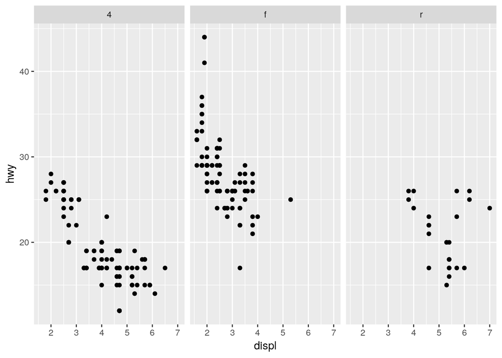

```r
ggplot(data = mpg) +
  geom_point(mapping = aes(x = displ, y = hwy)) +
  facet_grid(. ~ drv)
```

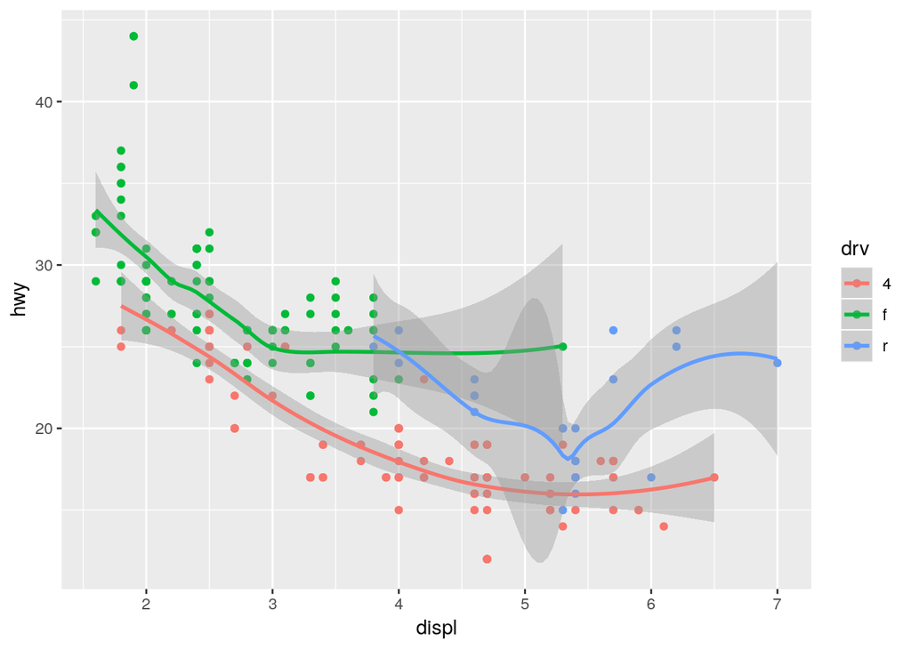

```r
ggplot(mpg, aes(displ, hwy)) +
  geom_point(aes(color = drv)) +
  geom_smooth(method = 'loess', aes(color = drv))
```

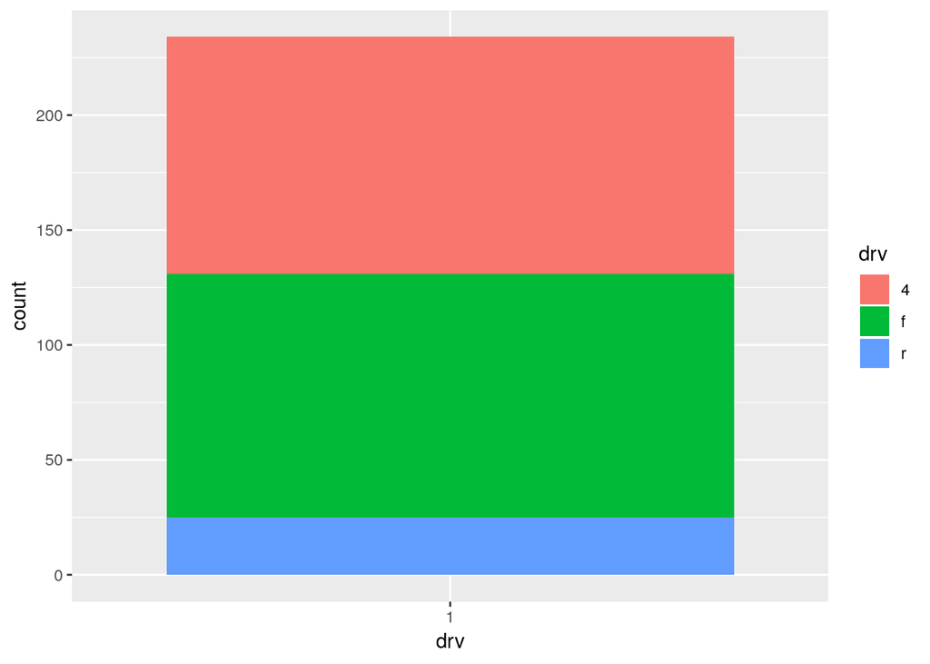

```r
ggplot(mpg, aes(drv)) +
  geom_bar(aes(x = factor(1), fill =drv))
```

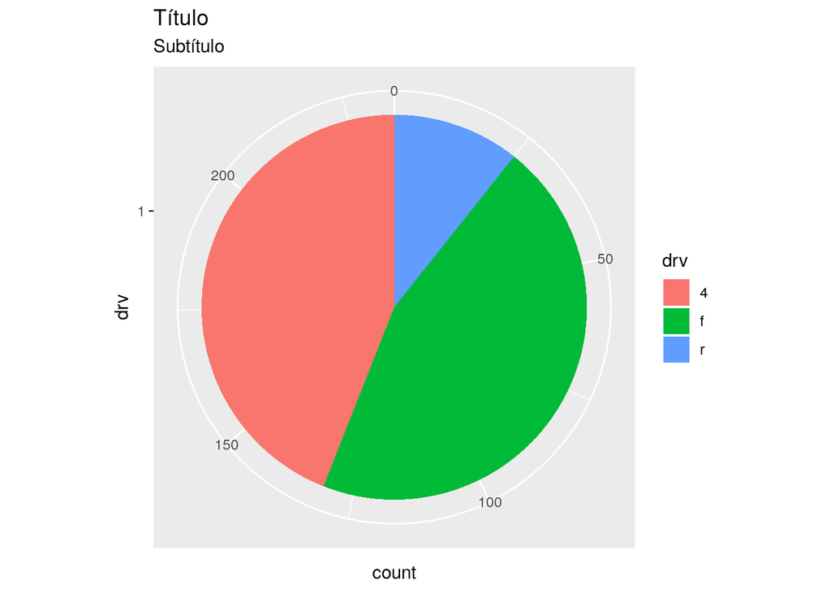

```r
ggplot(mpg, aes(drv)) +
  geom_bar(aes(x = factor(1), fill =drv)) +
  coord_polar(theta = "y") +
  labs(title = "Título",
       subtitle = "Subtítulo")
```

### Sobre nombres de variables

Solo se puede usar punto (.) y guión bajo (_), también mayúsculas. Mantener el criterio y listo!

### Símbolos en labs

Se puede usar la función `quote()` que es de `plotmath` y acepta una determinada sintaxis.

### Escalas

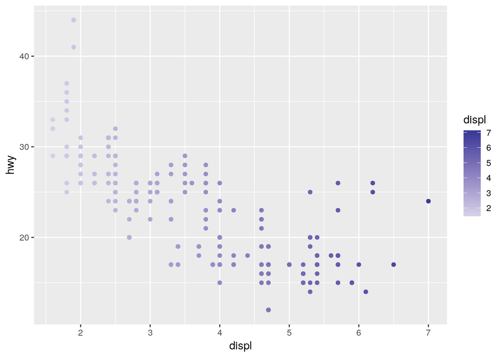

```r
ggplot(data = mpg) +
  geom_point(mapping = aes(x = displ, y = hwy, color = displ)) +
  scale_color_gradient2()
```